# Homework 7 - Ensemble Random Forest

### Dataset and Objective

The dataset consists of [Phishing Websites](https://www.kaggle.com/akashkr/phishing-website-dataset) from Kaggle. It uses 30 different features to determine whether or not a given website is a phishing website. A phishing website is a website which tries to steal information from users under the guise of looking and behaving like a legitimate website.

```r
library(caret)
set.seed(408)

phishing <- read.csv('phishing-dataset.csv')

# Row id not needed
phishing <- phishing[,-1]

# Factorize remaning columns
phishing[,] <- lapply(phishing[,], factor)
summary(phishing$Result)
```

```
##   -1    1
## 4898 6157
```

There are 4,898 instances of phishing websites and 6,157 legitimate websites My objective is to build a classifier that can use the 30 features given to determine the website class as phishing or legitimate.

### Explanation of features

```r
data.frame(t(phishing[1,]))
```

```
##                             X1
## having_IPhaving_IP_Address  -1
## URLURL_Length                1
## Shortining_Service           1
## having_At_Symbol             1
## double_slash_redirecting    -1
## Prefix_Suffix               -1
## having_Sub_Domain           -1
## SSLfinal_State              -1
## Domain_registeration_length -1
## Favicon                      1
## port                         1
## HTTPS_token                 -1
## Request_URL                  1
## URL_of_Anchor               -1
## Links_in_tags                1
## SFH                         -1
## Submitting_to_email         -1
## Abnormal_URL                -1
## Redirect                     0
## on_mouseover                 1
## RightClick                   1
## popUpWidnow                  1
## Iframe                       1
## age_of_domain               -1
## DNSRecord                   -1
## web_traffic                 -1
## Page_Rank                   -1
## Google_Index                 1
## Links_pointing_to_page       1
## Statistical_report          -1
## Result                      -1
```

The model has 30 features, below is a description of some and how they relate to whether or not the URL should be classified as a phishing site. For each feature, a value of 1 indicates legitimate, 0 indicates suspicious and -1 indicates phishing.

**URL_Length** - Between 54 and 75 is consideredsuspicious. Greater than 75 is classified as phishing.

**Shortening_Service** - Was a shortening service used to conceal the true length of the URL?

**SSLfinal_State**_ - If https is used, is the certificate issuer trusted? If not it’s suspicious. If https is not used, it’s considered phishing.

**Favicon** - Was the favicon loaded from a different domain?

**URL_of_Anchor** - Do more than 67% of of the `<a>` not contain any links? If so, it’s classified as phishing. If greater than 37% but less than 67% of the `<a>` tags do not contain links, then it’s considered suspicious.

**SFH** - Is form data submitted to an external domain or is no action taken upon submission?

**Submitting_to_email** - Are form submissions emailed?

**on_mouseover** - Is JavaScript used to change the status bar in the browser?

**web_traffic** - Does the website have a rank greater than 100,000 in the Alex database? The latter database ranks the popularity of a website by the number of visitors in addition to the number of websites they visit.

**Google_Index** - Has the site been indexed by Google?

**Statistical_report** Does the IP belong to a known list of phishing IPs?

### Training the Random Forest

```r
trainIndex <- createDataPartition(phishing$Result, p = 0.75, list=FALSE)
trainData <- phishing[trainIndex,]
trainTest <- phishing[-trainIndex,]
trControl <- trainControl(method = "repeatedcv", number = 10, repeats = 10)

rfModel <- train(Result ~ ., data = trainData, method = "rf", metric = "Kappa", trControl = trControl, tuneGrid = data.frame(mtry = c(1, 2, 4, 8, 16)))
```

```r
rfModel
```

```
## Random Forest
##
## 8292 samples
##   30 predictor
##    2 classes: '-1', '1'
##
## No pre-processing
## Resampling: Cross-Validated (10 fold, repeated 10 times)
## Summary of sample sizes: 7464, 7463, 7463, 7463, 7462, 7463, ...
## Resampling results across tuning parameters:
##
##   mtry  Accuracy   Kappa
##    1    0.9018346  0.7974176
##    2    0.9500002  0.8983060
##    4    0.9606607  0.9201232
##    8    0.9651227  0.9292003
##   16    0.9677274  0.9344719
##
## Kappa was used to select the optimal model using the largest value.
## The final value used for the model was mtry = 16.
```

```r
confusionMatrix(rfModel)
```

```
## Cross-Validated (10 fold, repeated 10 times) Confusion Matrix
##
## (entries are percentual average cell counts across resamples)
##
##           Reference
## Prediction   -1    1
##         -1 42.3  1.2
##         1   2.0 54.5
##
##  Accuracy (average) : 0.9677
```

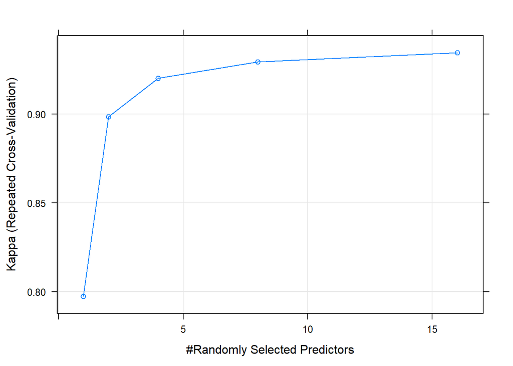

```r
plot(rfModel)
```

The model with the highest accuracy and kappa is one which selected from 16 candidate features at each split.

### Classifying the test data

```r
predictions <- predict(rfModel, newdata=trainTest[,-ncol(trainTest)])

confusionMatrix(predictions, trainTest$Result)
```

```
## Confusion Matrix and Statistics
##
##           Reference
## Prediction   -1    1
##         -1 1176   27
##         1    48 1512
##
##                Accuracy : 0.9729
##                  95% CI : (0.9661, 0.9786)
##     No Information Rate : 0.557
##     P-Value [Acc > NIR] : < 2e-16
##
##                   Kappa : 0.9449
##
##  Mcnemar's Test P-Value : 0.02092
##
##             Sensitivity : 0.9608
##             Specificity : 0.9825
##          Pos Pred Value : 0.9776
##          Neg Pred Value : 0.9692
##              Prevalence : 0.4430
##          Detection Rate : 0.4256
##    Detection Prevalence : 0.4354
##       Balanced Accuracy : 0.9716
##
##        'Positive' Class : -1
##
```

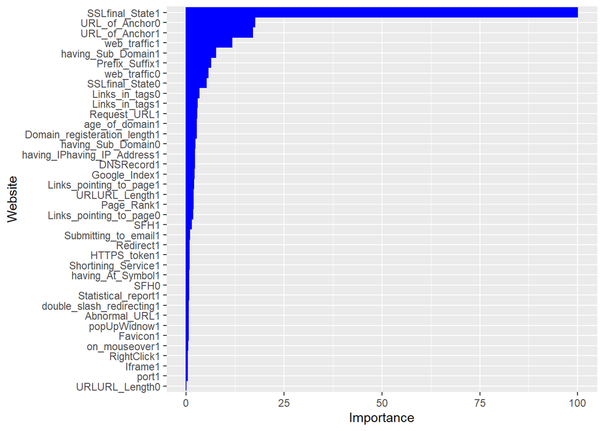

```r
library(ggplot2)

rfVarImp <- varImp(rfModel, scale = TRUE)

rfVarImp <- data.frame(rownames(rfVarImp$importance), rfVarImp$importance$Overall)

names(rfVarImp) <- c('Website', 'Importance')

rfVarImp <- transform(rfVarImp, Website = reorder(Website, Importance))

ggplot(data=rfVarImp, aes(x=Website, y=Importance)) +
  geom_bar(stat = 'identity',colour = "blue", fill = "blue") +
  coord_flip()
```

The features which are the highest predictors in classifying a phishing website, according to this model, are whether or not the website uses SSL/TLS and has a trusted certificate, the percentage of anchor tags (`<a>`) on the page which contain links and the number of visitors to the website.